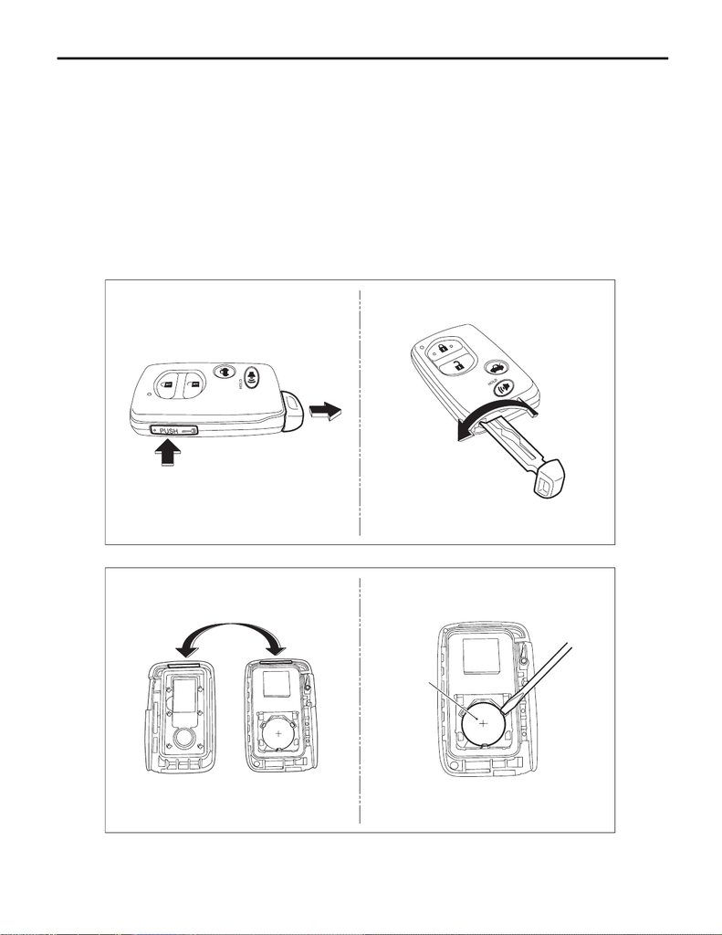

SL-85

Access Key

SECURITY AND LOCKS

26.Access Key

A: REMOVAL

NOTE:

Refer to keyless transmitter for model without keyless access. <Ref. to SL-82, KEYLESS TRANSMITTER

BATTERY, REMOVAL, Keyless Transmitter.>

1. ACCESS KEY BATTERY

CAUTION:

To prevent static electricity damage to the access key printed circuit board, touch the steel area of

building with hand to discharge static electricity carried on body or clothes before disassembling the

access key.

1) Push the lock button and remove the mechanical key from the access key.

2) Insert the mechanical key into the slit of the access key to open the case.

3) Insert a flat tip screwdriver to remove the battery (A) from the case.

SL-02515

SL-01615

(A)

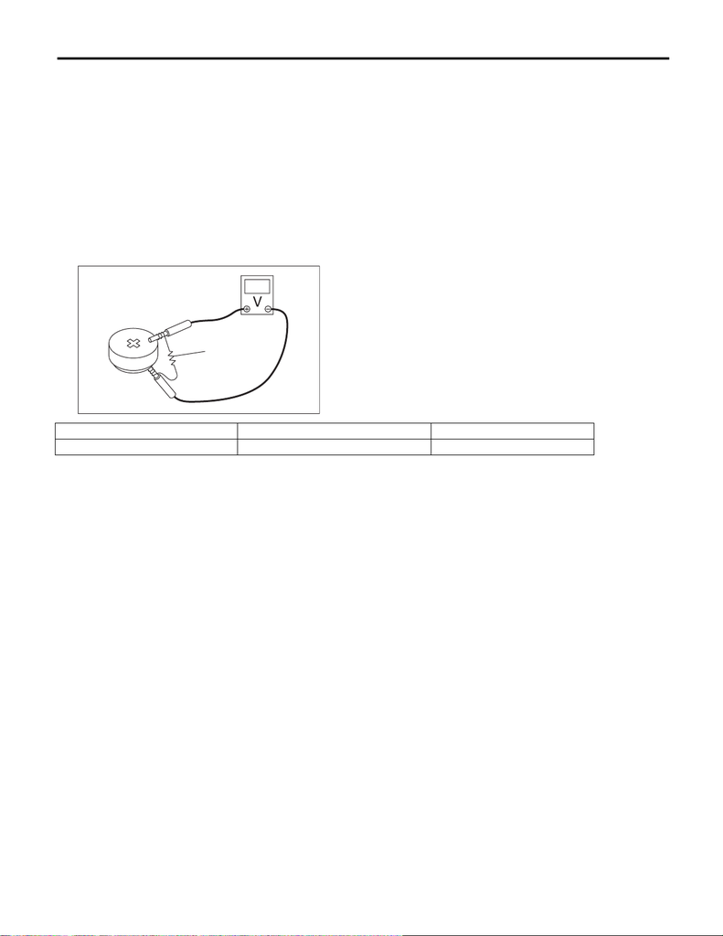

SL-86

Access Key

SECURITY AND LOCKS

B: INSTALLATION

1. ACCESS KEY BATTERY

Install each part in the reverse order of removal.

C: INSPECTION

1. ACCESS KEY BATTERY

Measure the access key battery voltage.

Preparation tool:

Circuit tester

NOTE:

Complete the measurement within 5 seconds because the battery discharges during measurement.

Replace the battery if the inspection result is not within the standard value. (Use CR1632 V or equivalent.)

D: REPLACEMENT

1. ACCESS KEY REGISTRATION

NOTE:

• A maximum of seven access keys can be registered for each individual vehicle.

• When replacing or adding an access key, new registration of the access key is necessary.

• When the access key has been newly added, it is registered to the immobilizer system at the same time.

2. CLEARING ACCESS KEY REGISTRATION

Refer to the “REGISTRATION MANUAL FOR IMMOBILIZER” for clearing access key registration.

(A)

SL-00066

Battery terminal Inspection conditions Standard

(+) — (–) Connect resistor (A) 47 Ω 2.5 — 3.0 V